# Detecting Twitter Trolls

## Progress since 10/4

1. Focused on tweets instead of users, since it’s hard to collect all the data for a user.
2. Found 3 words lists: swear words http://www.noswearing.com/dictionary, insulting words http://onlineslangdictionary.com/thesaurus/words+meaning+insults+(list+of).html, bad words https://www.cs.cmu.edu/~biglou/resources/bad-words.txt. I combined 3 lists and remove repetitions.
3. Downloaded tweets that are potentially related to Pitt-Jolie divorce.
4. Matched each tweet with the combined bad words list. The tweets with >98 percentile number of matched are considered trolls.

```r
library(RCurl)
library(twitteR)
library(readr)
library(rvest)
library(dplyr)
```

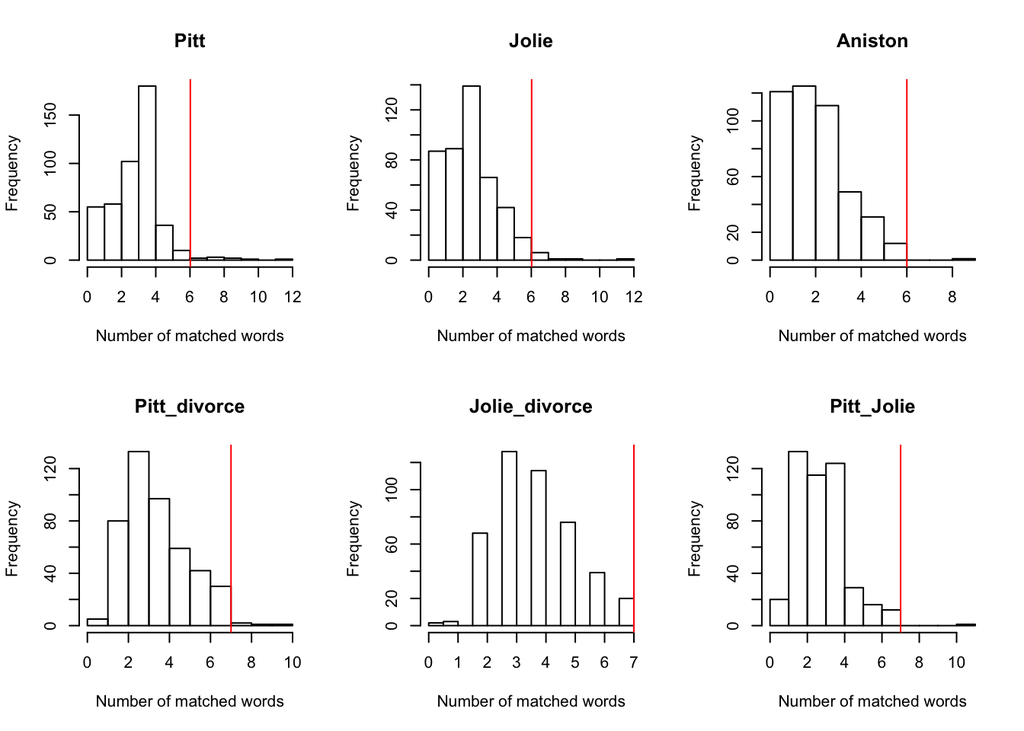

```r
library(stringr)

load('raw_data/oct_10_tweets_swear.RData')
swear = read.table('raw_data/swearwords_clean.txt',
                   stringsAsFactors = FALSE)[,1]
insult = read.table('raw_data/insultwords.txt',
                    stringsAsFactors = FALSE)[,1]
bad = read.table('raw_data/bad_words.txt',
                 stringsAsFactors = FALSE)[,1]
negwords = c(swear, insult, bad)
negwords = unique(tolower(negwords))


load('raw_data/oct_9_pitt_tweets.RData')
load('raw_data/oct_9_aniston_tweets.RData')
load('raw_data/oct_9_jolie_tweets.RData')
load('raw_data/oct_9_pitt_divorce_tweets.RData')
load('raw_data/oct_9_jolie_divorce_tweets.RData')
load('raw_data/oct_9_pitt_jolie_tweets.RData')

all.tweets = list(Pitt = tweets.pitt,
                  Jolie = tweets.jolie,
                  Aniston = tweets.aniston,
                  Pitt_divorce = tweets.pitt.divorce,
                  Jolie_divorce = tweets.jolie.divorce,
                  Pitt_Jolie = tweets.pitt.jolie)
swear.num = list()
par(mfrow = c(2,3))
for (keyword in names(all.tweets)){
    tweetslist = all.tweets[[keyword]]
    swear.num[[keyword]]  = vector(length = length(tweetslist))
    for (i in 1:length(tweetslist)){
        tweet = tweetslist[[i]]
        text = gsub("[^a-zA-Z0-9 ]", '', tweet@.xData$text)
        swear.num[[keyword]][i] = sum(sapply(1:length(negwords), function(x) length(grep(tolower(negwords[x]), tolower(text)))>=1))
    }
    thr = quantile(swear.num[[keyword]], 0.98)
    hist(swear.num[[keyword]], xlab = 'Number of matched words', main = keyword)
    abline(v = thr, col = 2)
}
```

Print identified trolls

```r
for (keyword in names(all.tweets)){
    tweetslist = all.tweets[[keyword]]
    print(paste0('TWEETS ABOUT ', keyword))
    for (i in 1:length(tweetslist)){
        if (swear.num[[keyword]][i] >= thr){
            print(tweetslist[[i]])
        }
    }
}
```

```
## [1] "TWEETS ABOUT Pitt"
## [1] "irmanbooo: RT @DPRK_News: Marshal Kim Jong-Un said to be shocked and saddened by divorce of good friends Angelina Jolie and Brad Pitt."
## [1] "adellapasos: You won't believe who's handling Angelina Jolie's divorce from Brad Pitt ... https://t.co/vhGHYTgbXG via @popsugar https://t.co/OaALGLNrw2"
## [1] "wjmaggos: Fuck Drumpf but stop pretending like you care. What if it had been Bill Clinton? Or Brad Pitt? Or Ellen DeGeneres? #grabgate"
## [1] "bubusher: [assman] if you wouldnt fuck brad pitt then you're gay"
## [1] "fatimah02281505: RT @keithahodges: @tariqnasheed and numerous fake white Jesus movies and white brad Pitt last Mexican and fake original birth of nation mad…"
## [1] "Vet4trump16: @daylinleach boo hooo! \xed\xa0\xbd\xed\xb2\xa5BUSTED LIAR\xed\xa0\xbd\xed\xb2\xa5 P.S. I DIED LAUGHING AT THE \"PEOPLE SAY I LOOK LIKE BRAD PITT\" voices in your head don't count"
## [1] "KimFinnis: RT @christinamcghee: #Truthbombs about #parenting &amp; #divorce for A-listers #BradPitt &amp; #AngelinaJolie.  Hit home? Weigh in. #children  http…"
## [1] "christinamcghee: #Truthbombs about #parenting &amp; #divorce for A-listers #BradPitt &amp; #AngelinaJolie.  Hit home? Weigh in. #children… https://t.co/FQhGsrdSKg"
## [1] "crlnlsndrs: @fakepixiebobcat @kellyoxford with a civic. Do you doubt Brad Pitt's ability to go ask any woman for sex and get a high return rate?"
## [1] "TWEETS ABOUT Jolie"
## [1] "irmanbooo: RT @DPRK_News: Marshal Kim Jong-Un said to be shocked and saddened by divorce of good friends Angelina Jolie and Brad Pitt."
## [1] "jacobmeglich: #nude photos of women from lehigh valley pa getting fucked angelina jolie lesbian sex scenes https://t.co/kZkUoWNmAC"
## [1] "adellapasos: You won't believe who's handling Angelina Jolie's divorce from Brad Pitt ... https://t.co/vhGHYTgbXG via @popsugar https://t.co/OaALGLNrw2"
## [1] "geniimuravev193: #hot twink sex angelina jolie fucking pics https://t.co/epO9XsuO8a"
```

[output cut: 77 more lines]

## Problems

1. Some matched tweets are not trolls but highly critical.
2. Hard to detect the trolls with no swear words.
3. Whether a tweet is a troll depends on the link it points to.

## Next step of troll identification

1. Find a list of known trolls and a list of random tweets. Add to the dictionary the words of significantly different frequencies between two list (most known troll lists are in images instead of text).
2. From the identified trolls, collect the words that have different frequencies with the list of random tweets and add to the dictionary.
3. Open the link in a tweet and grab key words from the title.
4. Identify tweets by friendship: if a persion is friends with several trolls, he/she is more likely to be a troll.

## Troll classification.

Existing dictionary consists of different parts. May classify a troll based on word frequencies in different parts.